# Introduction to R Markdown

Yang Shao

2024-07-10

## Introduction to R Markdown

R Markdown is a powerful tool that allows you to create dynamic documents integrating R code and its output with narrative text. This guide will help you get started with using R Markdown for your assignments.

### Prerequisites

1. **R**: Make sure you have R installed on your computer. You can download it from [CRAN](https://cran.r-project.org/).
2. **RStudio**: Install RStudio, an integrated development environment (IDE) for R, from [RStudio’s website](https://www.rstudio.com/products/rstudio/download/).

### Creating an R Markdown Document

1. **Open RStudio**.
2. **Create a New R Markdown File**:
   - Go to `File` -> `New File` -> `R Markdown...`
   - Fill in the details such as the title, author, and default output format (HTML is a good starting point).
   - Click `OK`.

### Structure of an R Markdown Document

An R Markdown document consists of three main parts:

1. **YAML Header**:
   - This section is at the top of the document, enclosed in `---`. It includes metadata like the title, author, and output format.
2. **Markdown Text**: Use regular Markdown syntax to add narrative text. Markdown allows you to format text using simple symbols.
3. **Code Chunks**: Code chunks are sections of the document that contain R code. They are enclosed in triple backticks and start with {r}.

```r
# This is an R code chunk
summary(cars)
```

```
##      speed           dist
##  Min.   : 4.0   Min.   :  2.00
##  1st Qu.:12.0   1st Qu.: 26.00
##  Median :15.0   Median : 36.00
##  Mean   :15.4   Mean   : 42.98
##  3rd Qu.:19.0   3rd Qu.: 56.00
##  Max.   :25.0   Max.   :120.00
```

Run a Code Chunk: Click the green triangle (Run Current Chunk) in the chunk header or press Ctrl + Shift + Enter (Cmd + Shift + Enter on Mac) with your cursor inside the chunk.

Adding and Running Code Chunks Insert a Code Chunk: You can insert a code chunk by clicking “Insert Chunk” button -> R in the RStudio toolbar. It looks like a small green plus sign (+), or by typing the chunk delimiters manually.

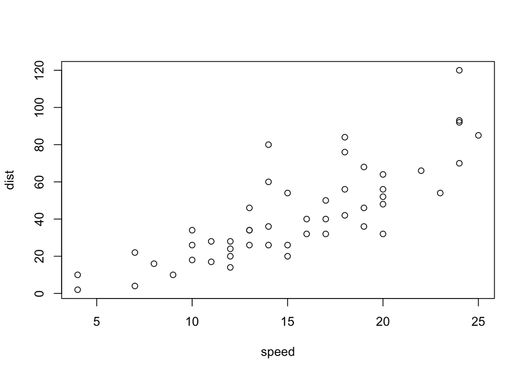

```r
plot(cars)
```

### Rendering the Document

Knit the Document: Click the Knit button at the top of the RStudio script editor. This will generate the output document in the format specified in the YAML header (e.g., HTML).